# USAID SCMS Health Logistics

### Issue no 3. String ‘N/A’ Sentinel in Shipment Mode

*State of the Problem:* The literal string `N/A` is used as a sentinel value in the Shipment Mode column. R’s `is.na()` returns FALSE for these values, meaning they would be treated as a legitimate fifth shipping mode in analyses.

```r
mode_dist <- raw %>%
  count(shipment_mode, sort = TRUE) %>%
  mutate(
    pct         = round(100 * n / nrow(raw), 1),
    is_sentinel = shipment_mode == "N/A"
  )

kable(mode_dist,
      col.names = c("Shipment Mode", "Count", "Percentage", "Is Sentinel"),
      caption = "Table 3: Shipment Mode Distribution") %>%
  kable_styling(bootstrap_options = c("striped", "hover"))
```

Table 3: Shipment Mode Distribution

| Shipment Mode | Count | Percentage | Is Sentinel |
| --- | --- | --- | --- |
| Air | 6113 | 59.2 | FALSE |
| Truck | 2830 | 27.4 | FALSE |
| Air Charter | 650 | 6.3 | FALSE |
| Ocean | 371 | 3.6 | FALSE |
| N/A | 360 | 3.5 | TRUE |

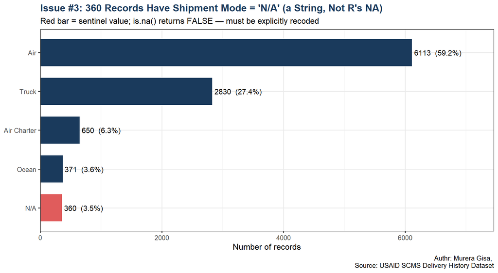

```r
p3 <- ggplot(mode_dist,
             aes(x = reorder(shipment_mode, n), y = n,
                 fill = is_sentinel)) +
  geom_col(width = 0.7, show.legend = FALSE) +
  geom_text(aes(label = paste0(n, "  (", pct, "%)")),
            hjust = -0.05, size = 3.8) +
  coord_flip() +
  scale_fill_manual(values = c("FALSE" = "#1A3A5C", "TRUE" = "#E05C5C")) +
  scale_y_continuous(expand = expansion(mult = c(0, 0.22))) +
  labs(
    title    = "Issue #3: 360 Records Have Shipment Mode = 'N/A' (a String, Not R's NA)",
    subtitle = "Red bar = sentinel value; is.na() returns FALSE — must be explicitly recoded",
    x = NULL, y = "Number of records",
    caption  = "Authr: Murera Gisa, \n Source: USAID SCMS Delivery History Dataset"
  ) +
  theme_bw(base_size = 12) +
  theme(plot.title = element_text(face = "bold", colour = "#1A3A5C"))

print(p3)
```

```r
ggsave("reports/figures/issue3_shipment_mode_na.png", p3, width = 10, height = 4, dpi = 150)
```

*Interpretation:* Figure 3 highlights 360 records (3.5%) where Shipment Mode contains the string “N/A” rather than a true NA value. These would be incorrectly treated as a separate shipping mode in any grouping operation.

**Business Impact:** Without recoding, any analysis by shipping mode would:

- Include a spurious “N/A” category
- Misrepresent the distribution of legitimate shipping modes
- Potentially skew mode-specific cost calculations

**Recommended Treatment:** Explicitly recode “N/A” to NA_character_ before any analysis:

```r
raw$Shipment_Mode_clean <- ifelse(raw$shipment_mode == "N/A", NA, raw$shipment_mode)
```

## Hypothesis Test: Air vs Truck Cost-per-KG for Heavy Loads

### Hypothesis Formulation

**Business Question:** For heavy loads which is greater than $500 Kgs$), is air freight significantly more expensive per kilogram than truck transport?

**Statistical Framework:**

- *H₀ (Null):* No significant difference in cost/kg between Air and Truck for load greater than 500 Kgs.
- *H₁ (Alternative):* Air costs is significantly more per kg than Truck for heavy loads

**Test Approach:** To test the above hypotheses we have used *Wilcoxon rank-sum test* which non-parametric test suitable for our skewed cost data.Therefore we have considered the *significance level* of $\alpha = 0.05$ and confidence level of $95\%$

### Data Preparation

```r
hyp_df <- raw %>%
  mutate(
    freight_usd = suppressWarnings(as.numeric(freight_cost_usd)),
    weight_kg   = suppressWarnings(as.numeric(weight_kilograms)),
    mode_clean  = case_when(
      shipment_mode == "Air"         ~ "Air",
      shipment_mode == "Air Charter" ~ "Air Charter",
      shipment_mode == "Truck"       ~ "Truck",
      shipment_mode == "Ocean"       ~ "Ocean",
      TRUE                             ~ NA_character_
    )
  ) %>%
  filter(
    !is.na(freight_usd), freight_usd > 0,
    !is.na(weight_kg),   weight_kg > 500,   # heavy loads only
    mode_clean %in% c("Air", "Truck", "Ocean")
  ) %>%
  mutate(cost_per_kg = freight_usd / weight_kg) %>%
  filter(cost_per_kg < quantile(cost_per_kg, 0.99, na.rm = TRUE))  # trim top 1% for visualization

# Descriptive statistics
hyp_summary <- hyp_df %>%
  group_by(Mode = mode_clean) %>%
  summarise(
    n           = n(),
    median_cpk  = round(median(cost_per_kg), 2),
    mean_cpk    = round(mean(cost_per_kg), 2),
    sd_cpk      = round(sd(cost_per_kg), 2),
    .groups     = "drop"
  )

kable(hyp_summary,
      col.names = c("Mode", "N", "Median ($/kg)", "Mean ($/kg)", "SD ($/kg)"),
      caption = "Table 4: Cost per KG Statistics by Mode (Loads >500 kg)") %>%
  kable_styling(bootstrap_options = c("striped", "hover"))
```

Table 4: Cost per KG Statistics by Mode (Loads >500 kg)

[output not shown]

### Statistical Analysis

```r
# Wilcoxon rank-sum test: one-sided Air > Truck
air_cpk   <- hyp_df$cost_per_kg[hyp_df$mode_clean == "Air"]
truck_cpk <- hyp_df$cost_per_kg[hyp_df$mode_clean == "Truck"]
wt        <- wilcox.test(air_cpk, truck_cpk, alternative = "greater")

# Effect size r = Z / sqrt(N)
z_stat    <- qnorm(wt$p.value / 2, lower.tail = FALSE)
effect_r  <- round(z_stat / sqrt(length(air_cpk) + length(truck_cpk)), 3)
multiplier <- round(median(air_cpk) / median(truck_cpk), 1)

# Create results table
test_results <- data.frame(
  Metric = c("Sample Size (Air)", "Sample Size (Truck)",
             "Median Air ($/kg)", "Median Truck ($/kg)",
             "Cost Multiplier", "P-value", "Effect Size (r)",
             "Effect Magnitude", "Decision (α=0.05)"),
  Value = c(length(air_cpk), length(truck_cpk),
            paste0("$", median(air_cpk)), paste0("$", median(truck_cpk)),
            paste0(multiplier, "×"),
            if (wt$p.value < 0.001) "< 0.001" else round(wt$p.value, 4),
            effect_r,
            if (effect_r >= 0.5) "Large" else if (effect_r >= 0.3) "Medium" else "Small",
            if (wt$p.value < 0.05) "REJECT H₀" else "FAIL TO REJECT H₀")
)

kable(test_results, col.names = c("Metric", "Value"),
      caption = "Table 5: Wilcoxon Rank-Sum Test Results") %>%
  kable_styling(bootstrap_options = c("striped", "hover"))
```

Table 5: Wilcoxon Rank-Sum Test Results

[output not shown]

### Visualization

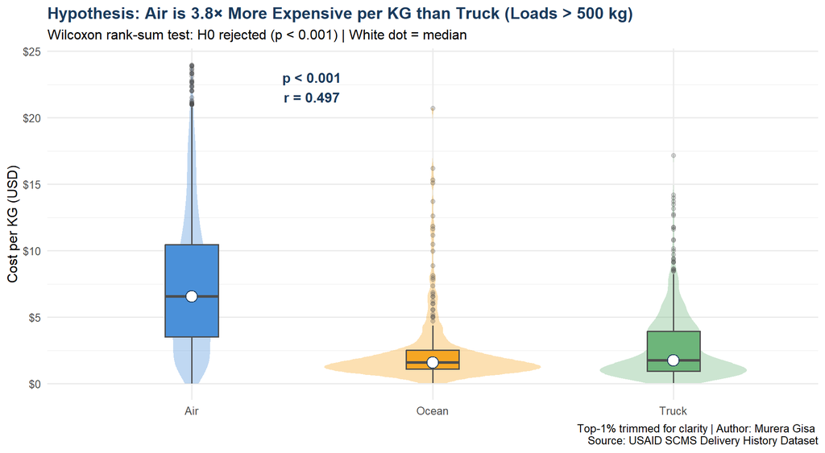

```r
p4 <- hyp_df %>%
  filter(mode_clean %in% c("Air", "Truck", "Ocean")) %>%
  ggplot(aes(x = mode_clean, y = cost_per_kg, fill = mode_clean)) +
  geom_violin(alpha = 0.35, colour = NA, trim = TRUE) +
  geom_boxplot(width = 0.22, outlier.alpha = 0.25, colour = "grey30") +
  stat_summary(fun = median, geom = "point",
               shape = 21, size = 4.5, fill = "white", colour = "#1A3A5C") +
  scale_fill_manual(values = c(Air = "#4A90D9", Truck = "#6DB57A", Ocean = "#F5A623"),
                    guide  = "none") +
  scale_y_continuous(labels = dollar_format()) +
  annotate("text", x = 1.5, y = max(hyp_df$cost_per_kg) * 0.93,
           label = paste0("p ", if (wt$p.value < 0.001) "< 0.001" else round(wt$p.value, 3),
                          "\nr = ", effect_r),
           size = 4.2, colour = "#1A3A5C", fontface = "bold") +
  labs(
    title    = paste0("Hypothesis: Air is ", multiplier,
                      "× More Expensive per KG than Truck (Loads > 500 kg)"),
    subtitle = "Wilcoxon rank-sum test: H0 rejected (p < 0.001) | White dot = median",
    x = NULL, y = "Cost per KG (USD)",
    caption  = "Top-1% trimmed for clarity | Author: Murera Gisa \n Source: USAID SCMS Delivery History Dataset"
  ) +
  theme_minimal(base_size = 12) +
  theme(plot.title = element_text(face = "bold", colour = "#1A3A5C"))

print(p4)
```

```r
ggsave("reports/figures/hypothesis_air_vs_truck.png", p4, width = 9, height = 5.5, dpi = 150)
```

### Business Interpretation

We have rejected the null hypothesis at $\alpha = 0.05$ with a confidence level of $95\%$. There is strong statistical evidence that air freight costs significantly more per kilogram than truck transport for loads exceeding $500$Kgs. This finding has important implications for supply chain optimization as follow:

- *Cost-Benefit Analysis:* The 3.8 $\times$ cost premium for air freight must be justified by time sensitivity or accessibility requirements
- *Mode Selection Criteria:* Organizations should establish clear thresholds where truck transport is preferred unless delivery speed is critical
- *Budget Planning:* Air freight budgets should be 3.8$\times$ higher per kg than truck budgets for comparable heavy shipments

**The Analytical Notes concerning the Ocean Freight:** While included for reference, ocean freight shows the lowest median cost (1.6/kg), making it the most economical option for non-urgent heavy shipments with adequate lead time.

**CURIOUS QUESTION:** Which is the shipping volume per year?

```r
yearly <- raw %>%
  mutate(yr = year(dmy(scheduled_delivery_date))) %>%
  filter(!is.na(yr)) %>%
  count(yr)

kable(yearly, col.names = c("Year", "Shipment Count"),
      caption = "Table 6: Annual Shipment Volumes") %>%
  kable_styling(bootstrap_options = c("striped", "hover"))
```

Table 6: Annual Shipment Volumes

| Year | Shipment Count |
| --- | --- |
| 2006 | 65 |
| 2007 | 672 |
| 2008 | 1029 |
| 2009 | 1253 |
| 2010 | 1204 |
| 2011 | 1011 |
| 2012 | 1273 |
| 2013 | 1272 |
| 2014 | 1528 |
| 2015 | 1017 |

The table 6 shows that the Peak Year: 2014 with 1528 shipments, representing the highest operational volume in the dataset.

## Conclusion

- This EDA has successfully identified three critical data quality issues that must be addressed before proceeding with downstream analysis.
- The hypothesis test confirms, with strong statistical evidence, that air freight carries a significant cost premium over truck transport for heavy loads. The analysis finds that it has direct implications on supply chain optimization.
- The documented issues and recommended solutions provide a clear roadmap for the data cleaning phase, ensuring that subsequent modeling and reporting will be built on a solid, trustworthy foundation.

## Data Story Telling

This section answers some questions eventhough it is presented in both detailed (`shiny dashbaord`) and superset dashboards

### Question 1: Supply Chain Health

> Which countries have the highest average freight costs?

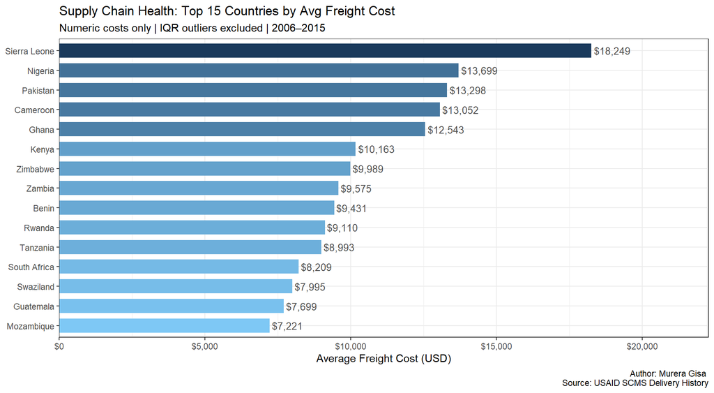

### QUESTION 2: Operation Efficiency

> Tuelve months trend of on-time delivey

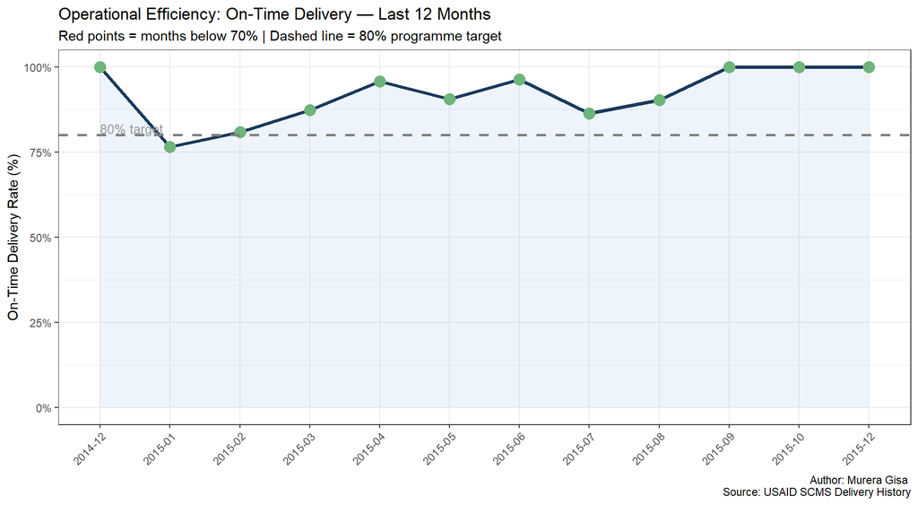

### Data Story and Insight

```
##   Air median $/kg   : $10.02
```

```
##   Truck median $/kg : $2.50
```

```
##   Multiplier        : 4.0x
```

```
##   Air on-time       : 90%
```

```
##   Truck on-time     : 84%
```

[figure not shown]

### Historical Trends

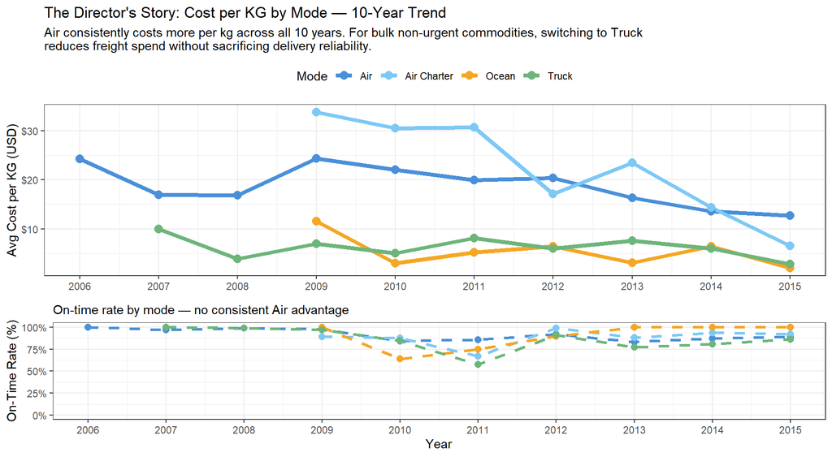

```r
#' Comprehensive Data Quality Check for SCMS Dataset
#' @param df Raw SCMS dataframe
#' @return List of quality issues and recommendations

check_scms_quality <- function(df) {
  issues <- list()

  # Issue 1: Non-numeric freight
  freight_text <- sum(!str_detect(df$`Freight Cost (USD)`, "^\\d") &
                       !is.na(df$`Freight Cost (USD)`))
  issues$freight_non_numeric <- list(
    count = freight_text,
    pct = round(100 * freight_text / nrow(df), 1),
    recommendation = "Classify into: numeric, 'Included', 'See row', or missing"
  )

  # Issue 2: Outliers
  numeric_vals <- suppressWarnings(as.numeric(df$`Freight Cost (USD)`))
  q3 <- quantile(numeric_vals, 0.75, na.rm = TRUE)
  q1 <- quantile(numeric_vals, 0.25, na.rm = TRUE)
  iqr <- q3 - q1
  outliers <- sum(numeric_vals > (q3 + 1.5 * iqr), na.rm = TRUE)
  issues$freight_outliers <- list(
    count = outliers,
    pct = round(100 * outliers / sum(!is.na(numeric_vals)), 1),
    recommendation = "Flag with IQR method; use median for robust averages"
  )

  # Issue 3: "N/A" sentinel
  na_strings <- sum(df$`Shipment Mode` == "N/A", na.rm = TRUE)
  issues$mode_na_string <- list(
    count = na_strings,
    pct = round(100 * na_strings / nrow(df), 1),
    recommendation = "Recode 'N/A' to NA_character_ before analysis"
  )

  return(issues)
}
```

**Conclusion:** You need only to load the dataset with the same column names as our data [Supply Chain Shipment Pricing Data](https://www.kaggle.com/datasets/apoorvwatsky/supply-chain-shipment-pricing-data/data)